# Relative, absolute, mixed, structured, and R1C1 references in Excel

Brendan Clarke, NHS Education for Scotland, brendan.clarke2@nhs.scot

08/08/2024

## Welcome

- this session is for 🌶🌶 intermediate Excel users
- we’ll get going properly at 15.05
- you’ need Excel of some sort to follow along
- you’ll also need the [exercise workbook](https://nes-dew.github.io/KIND-training/excel/src/excel_references.xlsx)
- if you can’t access the chat, you might need to join our Teams channel: [tinyurl.com/kindnetwork](https://teams.microsoft.com/l/team/19%3AQZ7-PbFVcziG2piHLt1_ifey3I2cwFL0yBuTSS8vVao1%40thread.tacv2/conversations?groupId=106d08f3-9026-40e2-b3c7-87cd87304d58&tenantId=10efe0bd-a030-4bca-809c-b5e6745e499a)
- you can find session materials at [tinyurl.com/kindtrp](https://nes-dew.github.io/KIND-training/)

## The KIND network

- a social learning space for staff working with **k**nowledge, **i**nformation, and **d**ata across health, social care, and housing in Scotland
- we offer social support, free training, mentoring, community events, …
- [Teams channel](https://teams.microsoft.com/l/team/19%3AQZ7-PbFVcziG2piHLt1_ifey3I2cwFL0yBuTSS8vVao1%40thread.tacv2/conversations?groupId=106d08f3-9026-40e2-b3c7-87cd87304d58&tenantId=10efe0bd-a030-4bca-809c-b5e6745e499a) / [mailing list](https://forms.office.com/pages/responsepage.aspx?id=veDvEDCgykuAnLXmdF5JmpopIZB9ynRJnrPUHVFccipURjM2NkZJUkhGOFlQRjQxRFhVUTgwT0UwVyQlQCN0PWcu)

## Forthcoming Excel sessions

| Session | Date | Area | Level |
| --- | --- | --- | --- |
| Excel first steps | 09:30-10:30 Tue 3rd September 2024 | Excel | 🌶 :**beginner-level** |
| References and names in Excel | 09:30-10:30 Tue 10th September 2024 | Excel | 🌶 :**beginner-level** |
| Tidy data in Excel | 09:30-10:30 Tue 17th September 2024 | Excel | 🌶 :**beginner-level** |
| Excel tables | 09:30-10:30 Tue 24th September 2024 | Excel | 🌶 :**beginner-level** |
| Excel formatting | 09:30-10:30 Tue 1st October 2024 | Excel | 🌶 :**beginner-level** |
| Excel formulas | 09:30-10:30 Tue 8th October 2024 | Excel | 🌶 :**beginner-level** |

## Session outline

- this is an intermediate-level review of referencing techniques in Excel
- it’s a technical session, so we’ll concentrate on the how of referencing
- A1 references
  - relative
  - absolute
  - mixed
- structured references
- R1C1

## A1 references

- A1 references are the standard way that references are made in Excel
- A1 references are usually made up of a letter and a number (like **A2**, **B56**, …)
  - the letter stands for the column a cell is in
  - the number stands for the row
- we can use those references in formulas
  - `=A1` will copy the values from A1 into the current cell
- you can also use the `range operator` (`:`) to select several values - like `A1:A3`

## References

**Task**

1. using A1 references, can you populate the first three rows of the summary table in the `A1 referencing` sheet?
   1. Start date
   2. End date
   3. First duty manager
2. you might need to switch off **Calculated Columns** from the floatie

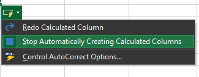

## Absolute vs relative references

- by default, A1 references are **relative**
  - if the formula moves, the reference will change

**Task**

1. try copy/pasting your three summary values:
   1. a few columns across
   2. a few rows down
2. what happens to your values?

## Absolute vs relative references

- as you’ve seen, relative references can cause problems
- you can change relative references to absolute (=fixed) references using `$`
  - `$A$1` refers to A1 **no matter what**
    - use this if you absolutely always want to refer to the same cell

## Absolute vs relative references

**Note**

- if you click in the formula bar, `F4` toggles absolute/relative

## Structured referencing

- most objects in Excel can be named - including cells, tables, and ranges
- structured referencing is a special case
  - `Table[Column]` syntax
  - shared across Power BI, PowerQuery…

**Task**

1. please switch to the `Structured referencing` sheet
2. sum up each of the three service columns in the summary table
- `=SUM(SR_table[service_a])` / `=SUM(SR_table[service_b])` / `=SUM(SR_table[service_c])`

## Implicit intersection

- you can convert a structured reference to a column to refer to a single value
- that’s done using the [**implicit intersection** operator](https://support.microsoft.com/en-gb/office/implicit-intersection-operator-ce3be07b-0101-4450-a24e-c1c999be2b34) `[@col]`
  - (if you’re using an older version of Excel, you might also see this written as `[@[Service_duration]]`)
- if you pick reference locations with the mouse, this is how Excel will render your references

**Task**

1. please try populating the `daily_total` by summing with implicit intersection
- `=SUM(SR_table[@[service_a]:[service_c]])`

## R1C1

- R1C1 gives an alternative way of referring to cells
- slightly more complicated, but more precise, and less confusing
- largely encountered in VBA, but available and helpful in standard Excel

## R1C1

**Task**

1. Switch to the `R1C1 referencing` sheet
2. switch to inspect formulas (`Ctrl` + backtick)
3. Have a look at the formula in the `First name` column
4. Now switch your workbook to R1C1 by `File` > `Options` > `Formulas` > `R1C1 reference style`

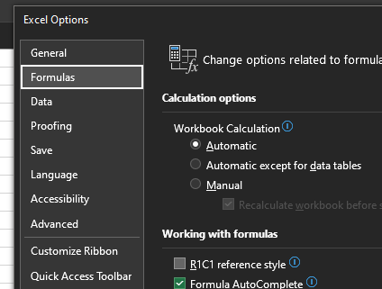

## R1C1

- column letters (A, B, C,…) are replaced by numbers
- row numbers remain as row numbers
  - R1C1 = A1
  - R2C8 = H2

**Task**

1. Have another look at the formula in the `First name` column - it should be much easier to conclude that this is the same formula in every row

## Types of R1C1 referencing

- three kinds of R1C1 reference:
  - absolute reference = specify a row and column number (`R2C2`)
  - relative reference by adding a numeric offset in square brackets (`R2C[-6]`)
  - implicit intersection-like “give me this row’s column 2” by using a bare R/C (`RC2`)
- a much nicer way of doing mixed referencing

**Task**

1. in R16C4, please populate the four rows of the `Age` column in the summary table using R1C1

## Why bother with R1C1?

- R1C1 adds a bit of complexity to simple formulas
- but it makes complicated formulas (and repeated formulas) **much** easier to understand
- this is a big help when working with more complex Excel documents - particularly if you’re debugging something that’s gone wrong

## Forthcoming Excel sessions

| Session | Date | Area | Level |
| --- | --- | --- | --- |
| Excel first steps | 09:30-10:30 Tue 3rd September 2024 | Excel | 🌶 :**beginner-level** |
| References and names in Excel | 09:30-10:30 Tue 10th September 2024 | Excel | 🌶 :**beginner-level** |
| Tidy data in Excel | 09:30-10:30 Tue 17th September 2024 | Excel | 🌶 :**beginner-level** |
| Excel tables | 09:30-10:30 Tue 24th September 2024 | Excel | 🌶 :**beginner-level** |
| Excel formatting | 09:30-10:30 Tue 1st October 2024 | Excel | 🌶 :**beginner-level** |
| Excel formulas | 09:30-10:30 Tue 8th October 2024 | Excel | 🌶 :**beginner-level** |

## Feedback and resources

- please can I ask for some feedback - takes less than a minute, completely anonymous, helps people like you find the right training for them